# ABS tourist accomodation data 02

Radoslaw Panczak

29 June, 2018

# 1 Summary

This is an overview of data preparation for ‘8635.0 - Tourist Accommodation, Australia, 2015-16’ [dataset](http://www.abs.gov.au/AUSSTATS/abs@.nsf/Lookup/8635.0Main+Features12015-16?OpenDocument) from ABS.

In contrast to version 1 which prepared the data on SA2 level, this work uses states and Tourism Regions (version 2015) as spatial reference.

Additionally, more detail on type of accomodation is included.

# 2 Data preparation

## 2.1 Raw data

Data are openly available. Unfortunately they can only be dowloaded in form of horribly designed spreadsheets:

[figure not shown]

Note the empty cells! Comment for them says:

> *not available for publication but included in totals where applicable, unless otherwise indicated*

## 2.2 State level data

- Monthly values of **Guest Nights Occupied** (GNO) and **Room nights occupied** (RNO) were extracted
- These two figures were used to create monthly value of people per room as PPR = GNO / RNO
- PPR was calculated for three types of accomodation captured by the survey

## 2.3 TR level data - detailed

- Monthly values of **Guest Nights Occupied** (GNO) were extracted
- **Values are extracted per subcategory of accomodation (`Hotels and resorts`, `Motels, private hotels and guest houses`, `Serviced apartments`) and these figures will vary from totals per region when overall count of `Hotels, motels and serviced apartments` is used!**
- **Empty** cells are kept as missing data to differentiate fromlegitimate 0s.
- **Date** is formated as text
- Data are linked to spatial boundaries - unfortunately **2015 TRs** are used :/

## 2.4 TR level data - aggregated

- Monthly values of **Guest Nights Occupied** (GNO) were extracted
- **Values are extracted for all types of accomodation together,(ie. `Hotels, motels and serviced apartments` category)!**
- **Empty** cells are kept as missing data to differentiate fromlegitimate 0s.
- **Date** is formated as text
- Data are linked to spatial boundaries - unfortunately **2015 TRs** are used :/

# 3 Results - state level

## 3.1 Data structure

Skim summary statistics  
n obs: 288  
n variables: 5

Variable type: character

| variable | missing | complete | n | min | max | empty | n_unique |
| --- | --- | --- | --- | --- | --- | --- | --- |
| Category | 0 | 288 | 288 | 18 | 39 | 0 | 3 |
| date | 0 | 288 | 288 | 7 | 7 | 0 | 12 |
| State_short | 0 | 288 | 288 | 2 | 3 | 0 | 8 |
| STE_NAME16 | 0 | 288 | 288 | 8 | 28 | 0 | 8 |

Variable type: numeric

| variable | missing | complete | n | mean | sd | p0 | p25 | p50 | p75 | p100 | hist |
| --- | --- | --- | --- | --- | --- | --- | --- | --- | --- | --- | --- |
| PPR | 0 | 288 | 288 | 1.73 | 0.21 | 1.34 | 1.57 | 1.7 | 1.84 | 2.41 |  |

## 3.2 Monthly time trends in PPR

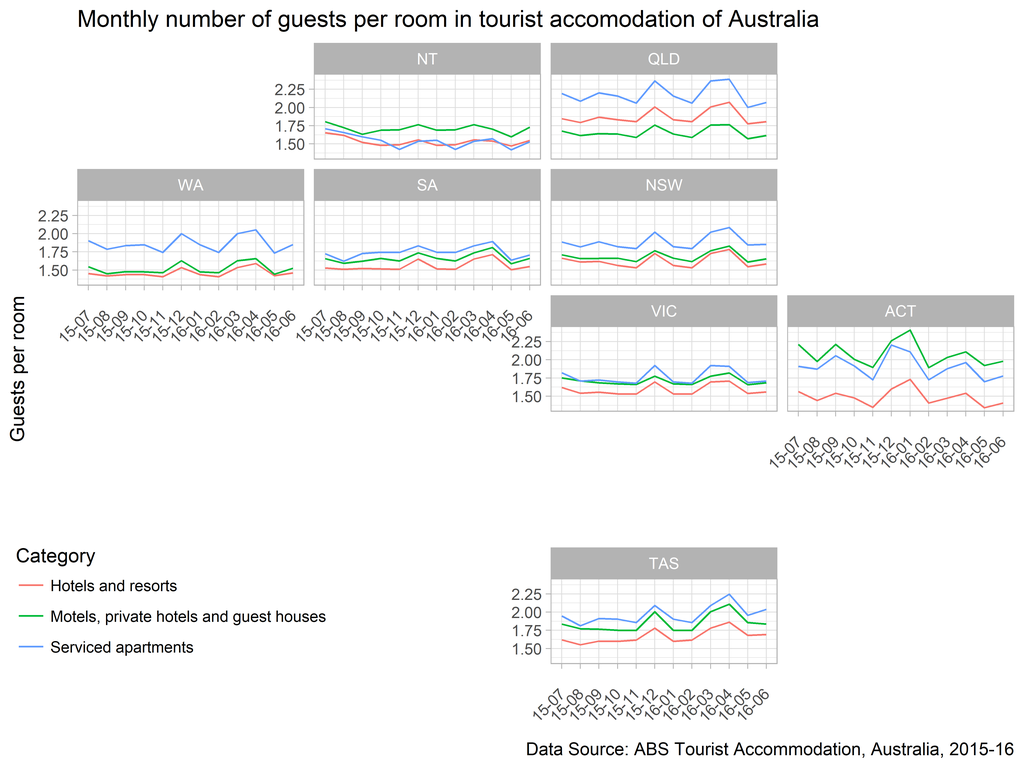

# 4 Results - TR level data

## 4.1 Data structure - aggregated

Skim summary statistics  
n obs: 924  
n variables: 6

Variable type: character

| variable | missing | complete | n | min | max | empty | n_unique |
| --- | --- | --- | --- | --- | --- | --- | --- |
| Category | 0 | 924 | 924 | 38 | 38 | 0 | 1 |
| date | 0 | 924 | 924 | 7 | 7 | 0 | 12 |
| State_long | 0 | 924 | 924 | 8 | 28 | 0 | 8 |
| State_short | 0 | 924 | 924 | 2 | 3 | 0 | 8 |
| TR_CODE15 | 0 | 924 | 924 | 5 | 31 | 0 | 77 |

Variable type: numeric

| variable | missing | complete | n | mean | sd | p0 | p25 | p50 | p75 | p100 | hist |
| --- | --- | --- | --- | --- | --- | --- | --- | --- | --- | --- | --- |
| GNO | 24 | 900 | 924 | 115335.63 | 244731.33 | 1431 | 15279.5 | 36137 | 88865.5 | 1579570 |  |

## 4.2 Data structure - detailed

Skim summary statistics  
n obs: 2772  
n variables: 6

Variable type: character

| variable | missing | complete | n | min | max | empty | n_unique |
| --- | --- | --- | --- | --- | --- | --- | --- |
| Category | 0 | 2772 | 2772 | 18 | 39 | 0 | 3 |
| date | 0 | 2772 | 2772 | 7 | 7 | 0 | 12 |
| State_long | 0 | 2772 | 2772 | 8 | 28 | 0 | 8 |
| State_short | 0 | 2772 | 2772 | 2 | 3 | 0 | 8 |
| TR_CODE15 | 0 | 2772 | 2772 | 5 | 31 | 0 | 77 |

Variable type: numeric

| variable | missing | complete | n | mean | sd | p0 | p25 | p50 | p75 | p100 | hist |
| --- | --- | --- | --- | --- | --- | --- | --- | --- | --- | --- | --- |
| GNO | 868 | 1904 | 2772 | 52392.04 | 107636.55 | 0 | 5382.25 | 18204.5 | 48654.5 | 920782 |  |

## 4.3 Monthly time trends in GNO (aggregated, absolute)

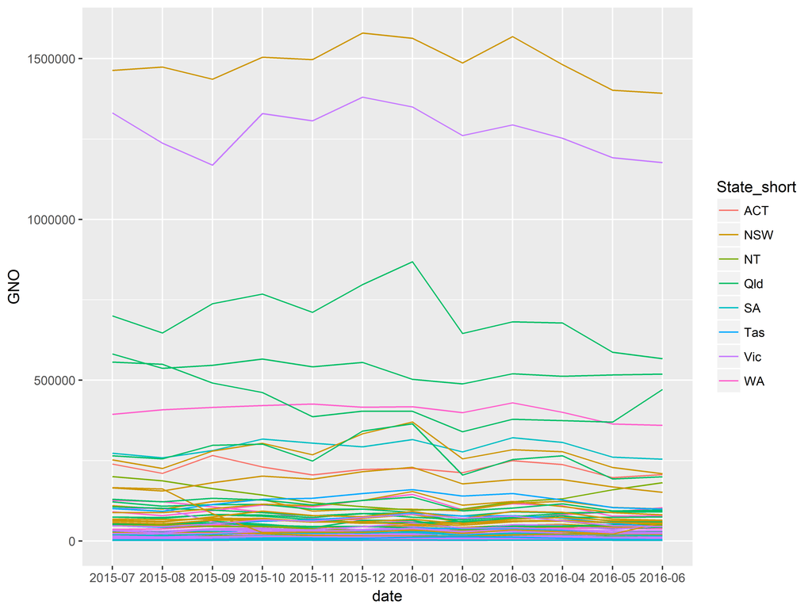

## 4.4 Monthly time trends in GNO (detailed, absolute)

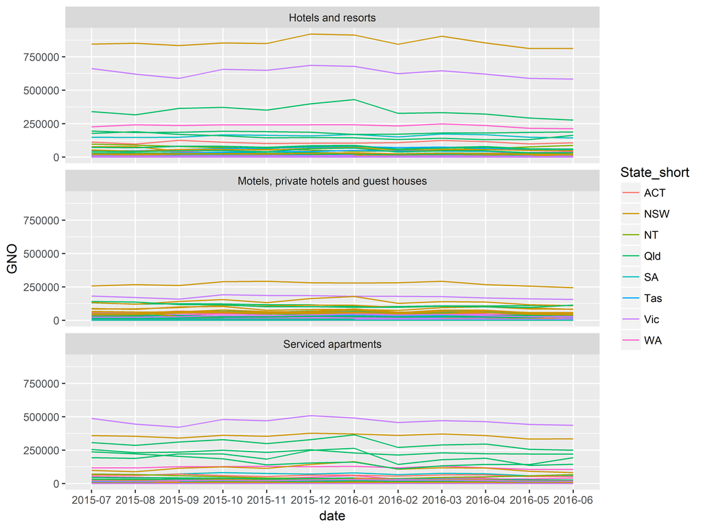

## 4.5 Monthly time trends in GNO (aggregated, relative)

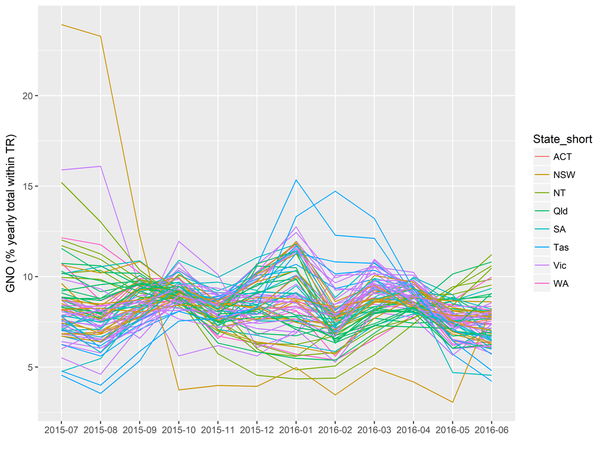

## 4.6 Monthly time trends in GNO (detailed, relative)

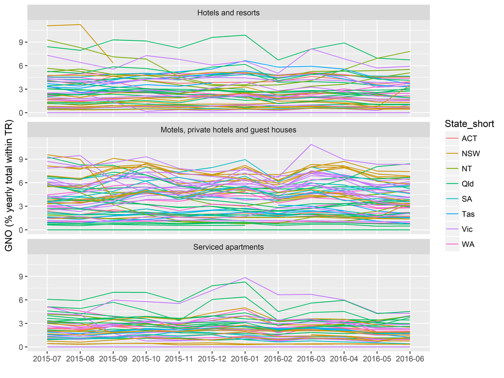